```r
require(dplyr)
require(lubridate)
```

```r
require(ggplot2)
```

#### This book has the following sheets:

#### Customer Acquisition: At the time of card issuing, company maintains

#### the details of customers.

#### Spend (Transaction data): Credit card spend for each customer

#### Repayment: Credit card Payment done by customer

#### Following are some of Watson’s questions to a Consultant (like you) to

#### understand the customers spend & repayment behavior.

#### 1. In the above dataset,

#### a. Incase age is less than 18, replace it with mean of age values.

#### b. Incase spend amount is more than the limit, replace it with 50% of that

#### customer’s limit. (customer’s limit provided in acquisition table is the per

#### transaction limit on his card)

```r
Customer_Acqusition <- read.csv("Customer Acqusition.csv")

spend <- read.csv("spend.csv")

Repayment <- read.csv("Repayment.csv")


head(Customer_Acqusition)
```

```
##   No Customer Age      City  Product  Limit Company       Segment
## 1  1       A1  76 BANGALORE     Gold 500000      C1 Self Employed
## 2  2       A2  71  CALCUTTA   Silver 100000      C2  Salaried_MNC
## 3  3       A3  34    COCHIN Platinum  10000      C3  Salaried_Pvt
## 4  4       A4  47    BOMBAY Platinum  10001      C4          Govt
## 5  5       A5  56 BANGALORE Platinum  10002      C5 Normal Salary
## 6  6       A6  70     DELHI   Silver 100000      C6 Self Employed
```

```r
head(spend)
```

```
##   Sl.No. Customer     Month      Type    Amount
## 1      1       A1 12-Jan-04 JEWELLERY 485470.80
## 2      2       A1  3-Jan-04     PETRO 410556.13
## 3      3       A1 15-Jan-04   CLOTHES  23740.46
## 4      4       A1 25-Jan-04      FOOD 484342.47
## 5      5       A1 17-Jan-05    CAMERA 369694.07
## 6      6       A1 23-Feb-05   SANDALS 168285.60
```

```r
head(Repayment)
```

```
##   SL.No. Customer     Month   Amount  X
## 1     NA       A1 12-Jan-04 495414.8 NA
## 2      2       A1  3-Jan-04 245899.0 NA
## 3      3       A1 15-Jan-04 259490.1 NA
## 4      4       A1 25-Jan-04 437555.1 NA
## 5      5       A1 17-Jan-05 165972.9 NA
## 6      6       A1 23-Feb-05 365366.6 NA
```

##### There is an empty column in the Payment Data

##### Remove empty data from the column

```r
Repayment$X <- NULL
```

##### Check for NA Value

```r
sum(is.na(Customer_Acqusition))
```

```
## [1] 0
```

```r
sum(is.na(spend))
```

```
## [1] 0
```

```r
sum(is.na(Repayment))
```

```
## [1] 47
```

```r
summary(Repayment)
```

```
##      SL.No.         Customer            Month               Amount
##  Min.   :   2.0   Length:1523        Length:1523        Min.   :    55.9
##  1st Qu.: 376.5   Class :character   Class :character   1st Qu.:118604.9
##  Median : 751.0   Mode  :character   Mode  :character   Median :248008.2
##  Mean   : 751.0                                         Mean   :247890.1
##  3rd Qu.:1125.5                                         3rd Qu.:367236.9
##  Max.   :1500.0                                         Max.   :499930.7
##  NA's   :24                                             NA's   :23
```

#### 1. In the above dataset,

#### a. Incase age is less than 18, replace it with mean of age valuE

```r
Age <- ifelse(Customer_Acqusition$Age <18, round(mean(Customer_Acqusition$Age, na.rm = TRUE),0), Customer_Acqusition$Age )

Customer_Acqusition$Age <- Age
Customer_Acqusition$Age
```

```
##   [1] 76 71 34 47 56 70 26 67 79 54 35 51 29 46 25 52 78 34 27 27 57 27 51 53 35
##  [26] 38 24 36 72 25 63 41 19 34 55 60 61 47 78 37 46 50 21 28 67 49 28 42 39 69
##  [51] 59 50 21 46 43 60 37 32 74 28 44 39 46 77 41 77 54 46 33 46 34 63 75 51 36
##  [76] 66 35 71 60 39 65 52 37 70 59 25 27 63 72 46 41 78 56 31 62 54 58 51 35 36
```

##### All the customers with age less than 18 have been replaced by mean of the age.

#### b. Incase spend amount is more than the limit, replace it with 50% of that

```r
CUSTOMER_SPENT <- dplyr::left_join(Customer_Acqusition, spend, by = "Customer")

sum(is.na(CUSTOMER_SPENT))
```

```
## [1] 0
```

```r
Amount <- ifelse(CUSTOMER_SPENT$Amount > CUSTOMER_SPENT$Limit, CUSTOMER_SPENT$Limit*0.50, CUSTOMER_SPENT$Amount  )

CUSTOMER_SPENT$Amount <- Amount
CUSTOMER_SPENT$Amount
```

```
##    [1] 485470.80 410556.13  23740.46 484342.47 369694.07 168285.60  23370.20
##    [8] 440563.22  52208.65 346925.68 183839.61 344372.10 244534.68 155611.91
##   [15] 176372.82 394970.96 476702.09 361141.31  50000.00  50000.00  50000.00
##   [22]  50000.00  50000.00  75728.35  50000.00  50000.00  50000.00  50000.00
##   [29]  50000.00   5000.00   5000.00   5000.00   5000.00   5000.00   5000.00
##   [36]   5000.00   5000.00   5000.00   5000.00   5000.00   5000.50   5000.50
##   [43]   5000.50   5000.50   5000.50   5000.50   5000.50   5000.50   5000.50
##   [50]   5000.50   5000.50   5001.00   5001.00   5001.00   5001.00   5001.00
##   [57]   5001.00   5001.00   5001.00   5001.00   5001.00   5001.00   5001.00
##   [64]   5001.00   5001.00   5001.00   5001.00   5001.00  50000.00  74569.98
##   [71]  50000.00  89467.92  50000.00  50000.00  50000.00  50000.00  18162.30
##   [78]  50000.00  50000.00  50000.00  50000.00  50000.00  50000.00  50000.00
##   [85]  50000.00  50000.50  50000.50  50000.50  22964.17  50000.50  50000.50
##   [92]  30727.68  50000.50  50000.50  50000.50  50000.50  50000.50  50000.50
##   [99]  50000.50  50000.50  50000.50  50000.50  50001.00  50001.00  50001.00
```

[output cut: 200 more lines]

#### c. Incase the repayment amount is more than the limit, replace the repayment with the limit

```r
CUSTOMER_Repayment <- dplyr::left_join(Customer_Acqusition, Repayment, by = "Customer")

sum(is.na(CUSTOMER_Repayment))
```

```
## [1] 1
```

#### NA IS PRESENT IN USELESS COLUMN. THUS THERE IS NO NEED TO REMOVE THAT

```r
Amount <- ifelse(CUSTOMER_Repayment$Amount > CUSTOMER_Repayment$Limit, CUSTOMER_Repayment$Limit, CUSTOMER_Repayment$Amount)

CUSTOMER_Repayment$Amount <- Amount
CUSTOMER_Repayment$Amount
```

```
##    [1] 495414.75 245899.02 259490.06 437555.12 165972.88 365366.62  14473.41
##    [8] 350446.82 117964.43  79849.19 402099.78 169358.40 297176.74 186427.50
##   [15]  96670.70 429099.97 453027.64 187398.64 100000.00 100000.00 100000.00
##   [22] 100000.00  10274.00 100000.00 100000.00 100000.00 100000.00 100000.00
##   [29] 100000.00  10000.00  10000.00  10000.00  10000.00  10000.00  10000.00
##   [36]  10000.00  10000.00  10000.00  10000.00  10000.00  10001.00  10001.00
##   [43]  10001.00  10001.00  10001.00  10001.00  10001.00  10001.00  10001.00
##   [50]  10001.00  10001.00  10002.00  10002.00  10002.00   8797.07  10002.00
##   [57]  10002.00  10002.00  10002.00  10002.00  10002.00  10002.00   7276.60
##   [64]  10002.00  10002.00  10002.00  10002.00  10002.00 100000.00 100000.00
##   [71] 100000.00  54065.23 100000.00  27398.18 100000.00 100000.00 100000.00
##   [78] 100000.00 100000.00  48574.15  53215.28 100000.00 100000.00 100000.00
##   [85] 100000.00 100001.00  94582.65  85745.75  67065.56 100001.00  94004.28
##   [92] 100001.00  86674.88 100001.00 100001.00  47988.31 100001.00  55108.71
##   [99] 100001.00 100001.00 100001.00 100001.00 100002.00 100002.00 100002.00
```

[output cut: 200 more lines]

#### 2. From the above dataset create the following summaries:

#### a. How many distinct customers exist?

```r
DISTINCT_CUSTOMER <- dplyr::distinct(Customer_Acqusition, Customer)
DISTINCT_CUSTOMER
```

```
##     Customer
## 1         A1
## 2         A2
## 3         A3
## 4         A4
## 5         A5
## 6         A6
## 7         A7
## 8         A8
## 9         A9
## 10       A10
## 11       A11
## 12       A12
## 13       A13
## 14       A14
```

[output cut: 86 more lines]

```r
  length(DISTINCT_CUSTOMER$Customer)
```

```
## [1] 100
```

#### b. How many distinct categories exist?

```r
Distinct_Categories <- Customer_Acqusition %>% dplyr::group_by(Segment) %>% dplyr::summarise(Co_uNT = n() )
Distinct_Categories
```

```
## # A tibble: 5 x 2
##   Segment       Co_uNT
##   <chr>          <int>
## 1 Govt              29
## 2 Normal Salary     22
## 3 Salaried_MNC      13
## 4 Salaried_Pvt      13
## 5 Self Employed     23
```

#### c. What is the average monthly spend by customers?

###### CUSTOMER SPENT DATA WILL BE USED HERE

```r
CUSTOMER_SPENT$Month <-  lubridate::dmy(CUSTOMER_SPENT$Month)


CUSTOMER_SPENT$YEAR <- lubridate::year(CUSTOMER_SPENT$Month)

CUSTOMER_SPENT$MON_TH <- lubridate::month(CUSTOMER_SPENT$Month, label = TRUE)

Average_monthly_Spent <- CUSTOMER_SPENT %>% dplyr::group_by(YEAR,MON_TH) %>% dplyr::summarise(Average_Monthly_Spent = mean(Amount))
Average_monthly_Spent
```

```
## # A tibble: 30 x 3
## # Groups:   YEAR [3]
##     YEAR MON_TH Average_Monthly_Spent
##    <dbl> <ord>                  <dbl>
##  1  2004 Jan                  144234.
##  2  2004 Feb                  136998.
##  3  2004 Mar                  133708.
##  4  2004 Apr                  124622.
##  5  2004 May                  153327.
##  6  2004 Sep                  171579.
##  7  2004 Nov                   79642.
##  8  2005 Jan                  192272.
##  9  2005 Feb                  154334.
## 10  2005 Apr                  146431.
## # ... with 20 more rows
```

#### d. What is the average monthly repayment by customers?

```r
CUSTOMER_Repayment$Month <-  lubridate::dmy(CUSTOMER_Repayment$Month)

CUSTOMER_Repayment$YEAR <- lubridate::year(CUSTOMER_Repayment$Month)

CUSTOMER_Repayment$MON_TH <- lubridate::month(CUSTOMER_Repayment$Month, label = TRUE)

Average_monthly_Repayment <- CUSTOMER_Repayment %>% dplyr::group_by(YEAR,MON_TH) %>% dplyr::summarise(Average_Monthly_Repayment =mean(Amount))
Average_monthly_Repayment
```

```
## # A tibble: 30 x 3
## # Groups:   YEAR [3]
##     YEAR MON_TH Average_Monthly_Repayment
##    <dbl> <ord>                      <dbl>
##  1  2004 Jan                      159972.
##  2  2004 Feb                      125613.
##  3  2004 Mar                      177768.
##  4  2004 Apr                      175633.
##  5  2004 May                      151310.
##  6  2004 Sep                      118926.
##  7  2004 Nov                      119227.
##  8  2005 Jan                      181261.
##  9  2005 Feb                      157357.
## 10  2005 Apr                      121163.
## # ... with 20 more rows
```

#### e. If the monthly rate of interest is 2.9%, what is the profit for the bank for

#### each month? (Profit is defined as interest earned on Monthly Profit.

```
         ####  Monthly Profit = Monthly repayment – Monthly spend. Interest is
         ####  earned only on positive profits and not on negative amounts)
```

```r
monthly_Spent <- CUSTOMER_SPENT %>% dplyr::group_by(YEAR,MON_TH) %>% dplyr::summarise(Average_Monthly = sum(Amount))
monthly_Repayment <- CUSTOMER_Repayment %>% dplyr::group_by(YEAR,MON_TH) %>% dplyr::summarise(Average_Monthly = sum(Amount))
For_Profit <- cbind(monthly_Spent, monthly_Repayment)
```

```
## * YEAR -> YEAR...1
## * MON_TH -> MON_TH...2
## * Average_Monthly -> Average_Monthly...3
## * YEAR -> YEAR...4
## * MON_TH -> MON_TH...5
## * ...
```

```r
For_Profit <- dplyr::rename(For_Profit, "SPENT" = "Average_Monthly...3", "REPAY" = "Average_Monthly...6")

For_Profit <- dplyr::rename(For_Profit, "YEAR" = "YEAR...1", "MONTH" = "MON_TH...2")
```

#### DROP USELESS COLUMN

```r
For_Profit$YEAR...4 <- NULL

For_Profit$MON_TH...5 <- NULL

For_Profit$PROFIT <- For_Profit$REPAY- For_Profit$SPENT

PROFIT_PLUS <- For_Profit[For_Profit$PROFIT > 0, ]

PROFIT_PLUS$Profit_AMOUNT <- (PROFIT_PLUS$PROFIT*2.9)/100

PROFIT_PLUS
```

```
## # A tibble: 19 x 6
##     YEAR MONTH     SPENT     REPAY   PROFIT Profit_AMOUNT
##    <dbl> <ord>     <dbl>     <dbl>    <dbl>         <dbl>
##  1  2004 Jan   44279812. 44792021.  512209.        14854.
##  2  2004 Mar    1871913.  2666519.  794606.        23044.
##  3  2004 Apr    3489415.  5268980. 1779564.        51607.
##  4  2004 May    2146577.  3782760. 1636183.        47449.
##  5  2004 Nov    1114989.  1788399.  673410.        19529.
##  6  2005 May   21647612. 30818765. 9171152.       265963.
##  7  2005 Jul    1691243.  1799339.  108096.         3135.
##  8  2005 Aug    3967808.  5549412. 1581604.        45867.
##  9  2005 Oct    1258312.  1635219.  376907.        10930.
## 10  2005 Dec    1181824   2149429.  967605.        28061.
## 11  2006 Jan    1908375.  2453064.  544689.        15796.
## 12  2006 Feb    6236117.  7339729. 1103611.        32005.
## 13  2006 Mar   28583303. 31591838. 3008535.        87248.
## 14  2006 Apr   12665908. 16247639. 3581731.       103870.
## 15  2006 May    8046846. 14900518. 6853671.       198756.
## 16  2006 Jul    5294483.  6295653. 1001170.        29034.
## 17  2006 Sep    1993489.  2388295.  394806.        11449.
## 18  2006 Oct    2410188.  2447635.   37447.         1086.
## 19  2006 Dec    2101811.  2413907.  312096.         9051.
```

#### f. What are the top 5 product types?

```r
TOP_5_PRODUCT <- spend %>% dplyr::group_by(Type) %>% dplyr::summarise(COU_NT = n()) %>% dplyr::arrange(desc(COU_NT))
 Top_5_Type  <- head(TOP_5_PRODUCT,5)

Top_5_Type
```

```
## # A tibble: 5 x 2
##   Type         COU_NT
##   <chr>         <int>
## 1 PETRO           200
## 2 CAMERA          160
## 3 FOOD            160
## 4 AIR TICKET      147
## 5 TRAIN TICKET    132
```

#### g. Which city is having maximum spend?

###### Customer Spent Data is Used For Solution

```r
Maximum_Spend <- CUSTOMER_SPENT %>% dplyr::group_by(City) %>% dplyr::summarise(Total_Spend =
                                                sum(Amount), Percentage =
           round(sum(Amount)*100/sum(CUSTOMER_SPENT$Amount),2) ) %>% dplyr::arrange(desc(Total_Spend))
Maximum_Spend
```

```
## # A tibble: 8 x 3
##   City       Total_Spend Percentage
##   <chr>            <dbl>      <dbl>
## 1 COCHIN       45963514.      20.9
## 2 CALCUTTA     41108132.      18.7
## 3 BANGALORE    40461647.      18.4
## 4 BOMBAY       28603127.      13.0
## 5 CHENNAI      22128636.      10.1
## 6 TRIVANDRUM   15337156.       6.98
## 7 PATNA        15260587.       6.94
## 8 DELHI        10918287.       4.97
```

#### h. Which age group is spending more money? (Age Group 18-36,36-54,54-72,72+)

```r
CUSTOMER_SPENT$AGE_GROUP <-   ifelse(CUSTOMER_SPENT$Age <36, "YOUNG",
       ifelse(CUSTOMER_SPENT$Age <54, "MID_AGE",
              ifelse(CUSTOMER_SPENT$Age <72, "MATURE", "OLD")))


MOST_SPENT <- CUSTOMER_SPENT %>% dplyr::group_by(AGE_GROUP) %>% dplyr::summarise(Total_Spent =
                            sum(Amount), Percentage =
      round(sum(Amount)*100/sum(CUSTOMER_SPENT$Amount),2) ) %>% dplyr::arrange(desc(Percentage))
MOST_SPENT
```

```
## # A tibble: 4 x 3
##   AGE_GROUP Total_Spent Percentage
##   <chr>           <dbl>      <dbl>
## 1 MID_AGE    101980664.       46.4
## 2 YOUNG       61767510.       28.1
## 3 MATURE      29208692.       13.3
## 4 OLD         26824219.       12.2
```

#### i. Who are the top 10 customers in terms of repayment?

```r
  Top_Customers <- CUSTOMER_Repayment %>% dplyr::group_by(Customer) %>% dplyr::summarise(Total_Repayment =
                                                       sum(Amount)) %>% dplyr::arrange(desc(Total_Repayment))
Top_10_Customers <- head(Top_Customers,10)

Top_10_Customers
```

```
## # A tibble: 10 x 2
##    Customer Total_Repayment
##    <chr>              <dbl>
##  1 A61            10539143.
##  2 A60             9876291.
##  3 A13             9572001.
##  4 A43             8489871.
##  5 A45             8448335.
##  6 A12             8334760.
##  7 A14             7943269.
##  8 A44             7744730.
##  9 A39             7622483.
## 10 A42             7615461.
```

#### 3. Calculate the city wise spend on each product on yearly basis. Also include a

#### graphical representation for the same.

```r
YEARLY_CITY_PRODUCT_SPEND <-  CUSTOMER_SPENT %>% dplyr::group_by(YEAR,City,Product) %>%  dplyr::summarise(Total_Spend = sum(Amount))
YEARLY_CITY_PRODUCT_SPEND
```

```
## # A tibble: 72 x 4
## # Groups:   YEAR, City [24]
##     YEAR City      Product  Total_Spend
##    <dbl> <chr>     <chr>          <dbl>
##  1  2004 BANGALORE Gold        9289879.
##  2  2004 BANGALORE Platinum    1112732.
##  3  2004 BANGALORE Silver      1291853.
##  4  2004 BOMBAY    Gold        6987854.
##  5  2004 BOMBAY    Platinum     897265.
##  6  2004 BOMBAY    Silver       532089.
##  7  2004 CALCUTTA  Gold        7477141.
##  8  2004 CALCUTTA  Platinum    2037690.
##  9  2004 CALCUTTA  Silver       500006
## 10  2004 CHENNAI   Gold        1059618.
## # ... with 62 more rows
```

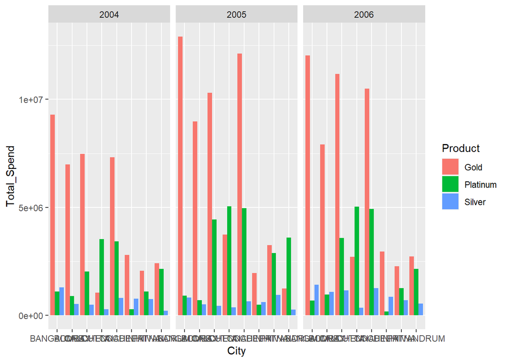

```r
ggplot2::ggplot(data = YEARLY_CITY_PRODUCT_SPEND) + aes(x= City, y = Total_Spend, fill = Product ) +
  geom_bar(stat = "identity", position = "dodge") + facet_grid(.~YEAR)
```

#### 4. Create graphs for

#### a. Monthly comparison of total spends, city wise

```r
CITY_WISE_spend <- CUSTOMER_SPENT %>% dplyr::group_by(City,MON_TH) %>% dplyr::summarise(TOTAL_SPEND =sum(Amount))
CITY_WISE_spend
```

```
## # A tibble: 96 x 3
## # Groups:   City [8]
##    City      MON_TH TOTAL_SPEND
##    <chr>     <ord>        <dbl>
##  1 BANGALORE Jan       9041797.
##  2 BANGALORE Feb       6734495.
##  3 BANGALORE Mar       5362903.
##  4 BANGALORE Apr       4207980.
##  5 BANGALORE May       6383115.
##  6 BANGALORE Jun       1330686.
##  7 BANGALORE Jul       2228218.
##  8 BANGALORE Aug        695062.
##  9 BANGALORE Sep        703018.
## 10 BANGALORE Oct       1091603.
## # ... with 86 more rows
```

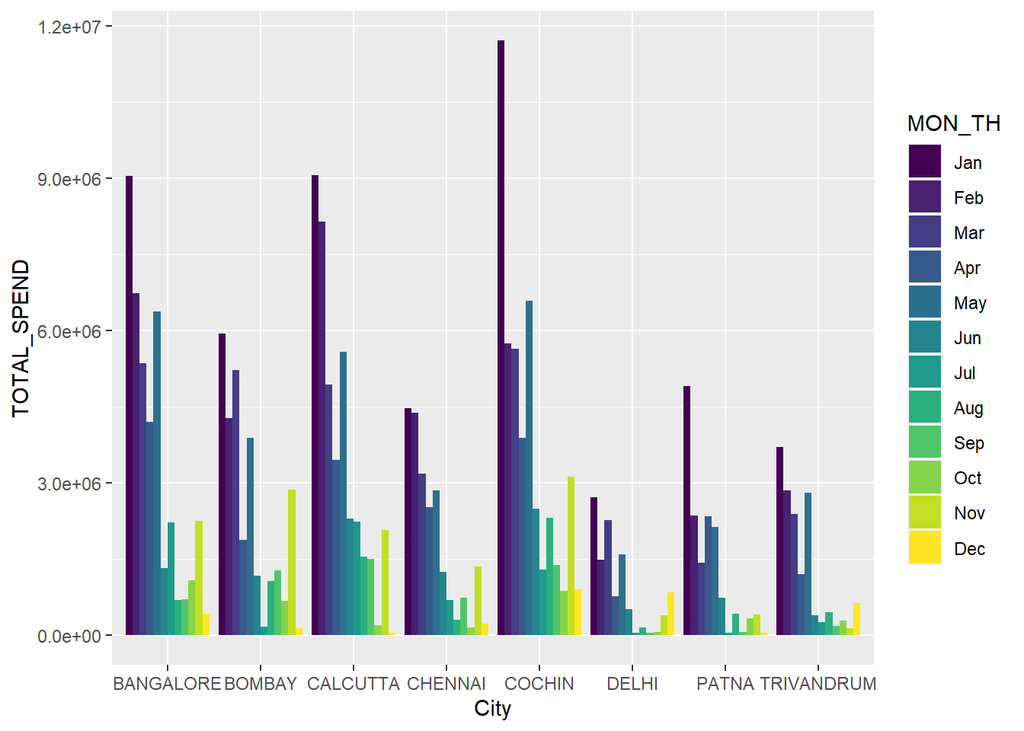

```r
ggplot2::ggplot(data = CITY_WISE_spend) + aes(x= City, y = TOTAL_SPEND, fill = MON_TH ) +
  geom_bar(stat = "identity", position = "dodge")
```

#### b. Comparison of yearly spend on air tickets

```r
Air_Ticket_Data<-    CUSTOMER_SPENT[CUSTOMER_SPENT$Type == "AIR TICKET",]

rownames(Air_Ticket_Data) <- NULL

YEARLY_AIR_TICKET <- Air_Ticket_Data %>% dplyr::group_by(YEAR) %>% dplyr::summarise(TOTAL_SPEND = sum(Amount))
```

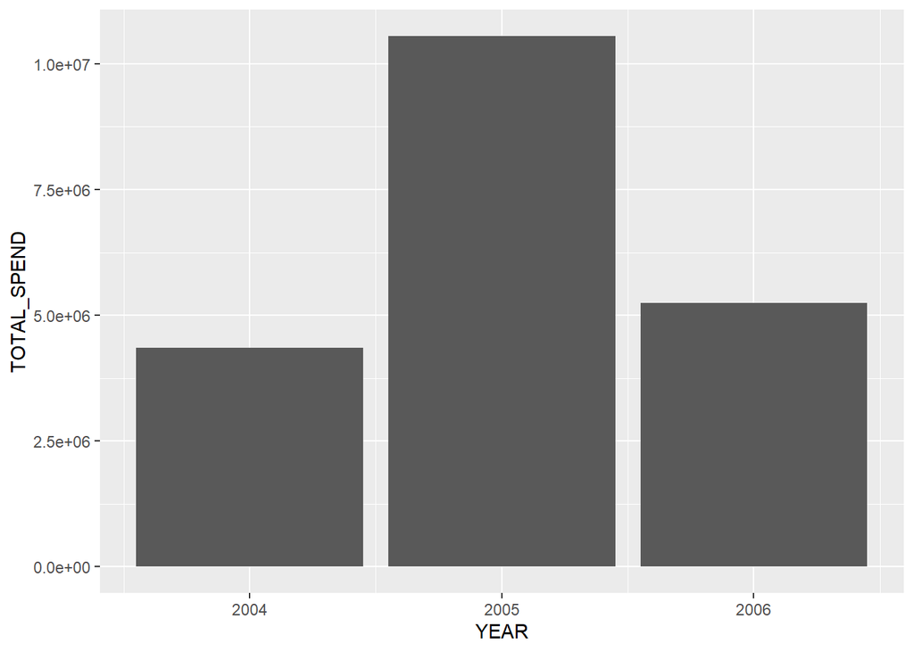

```r
ggplot2::ggplot(data = YEARLY_AIR_TICKET) + aes(x= YEAR, y = TOTAL_SPEND ) +
  geom_bar(stat = "identity", position = "dodge")
```

#### c. Comparison of monthly spend for each product (look for any seasonality that exists in terms of spend)

```r
MONTHLY_SPEND <- CUSTOMER_SPENT %>% dplyr::group_by(MON_TH,Product) %>% dplyr::summarise(ToTAL_SPEND =sum(Amount))
```

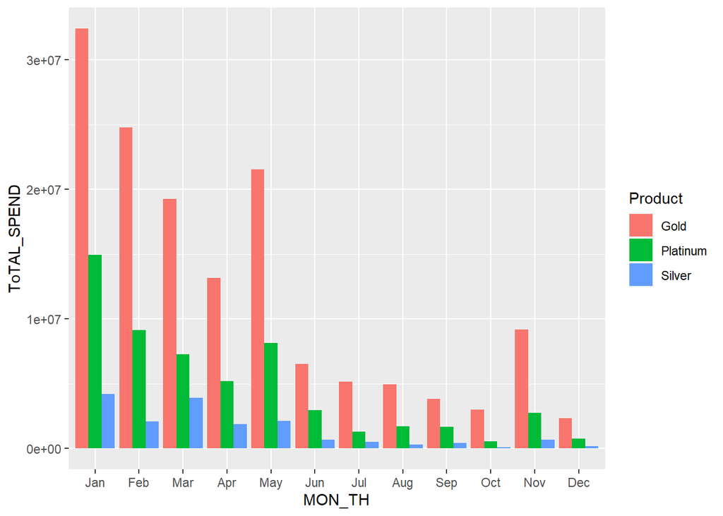

```r
ggplot2::ggplot(data = MONTHLY_SPEND) + aes(x= MON_TH, y = ToTAL_SPEND, fill = Product ) +
  geom_bar(stat = "identity", position = "dodge")
```

#### Spend is Decreasing in last Months as Compared to Starting Months

#### 5. Write user defined R function to perform the following analysis:

#### You need to find top 10 customers for each city in terms of their repayment

#### amount by different products and by different time periods i.e. year or

#### month. The user should be able to specify the product

#### (Gold/Silver/Platinum) and time period (yearly or monthly) and the function

#### should automatically take these inputs while identifying the top 10

#### customers.

```r
UDF_TOP10 <- function(DA_TA,YE_AR,Prod) {
P_DATA =   DA_TA[(DA_TA$YEAR == YE_AR) & (DA_TA$Product == Prod),]
  require(dplyr)
 Pre_Result = P_DATA %>% dplyr::group_by(Customer) %>% dplyr::summarise(TOTALS_PEND = sum(Amount)) %>% dplyr::arrange(desc(TOTALS_PEND))
  Result = head(Pre_Result,10)
  print(Result)

  }
```

####USe Character Data For Product ( Eg - “Gold”, “Silver”, “Platinum”)

```r
UDF_TOP10(CUSTOMER_Repayment, 2004,"Gold")
```

```
## # A tibble: 10 x 2
##    Customer TOTALS_PEND
##    <chr>          <dbl>
##  1 A42         3045915.
##  2 A60         2890722.
##  3 A14         2770261.
##  4 A45         2557947.
##  5 A61         2518155.
##  6 A1          2359798.
##  7 A12         2339081.
##  8 A13         2337013.
##  9 A44         2149384.
## 10 A43         1906497.
```

```r
UDF_TOP10(CUSTOMER_Repayment, 2004, "Silver")
```

```
## # A tibble: 10 x 2
##    Customer TOTALS_PEND
##    <chr>          <dbl>
##  1 A57         1000010
##  2 A22          953419.
##  3 A8           800016
##  4 A25          786338.
##  5 A46          713614.
##  6 A59          676558.
##  7 A23          664966.
##  8 A6           548574.
##  9 A58          533816.
## 10 A7           500005
```

```r
UDF_TOP10(CUSTOMER_Repayment, 2004, "Platinum")
```

```
## # A tibble: 10 x 2
##    Customer TOTALS_PEND
##    <chr>          <dbl>
##  1 A40         2576917.
##  2 A38         1951311.
##  3 A41         1752953.
##  4 A39         1342503.
##  5 A36          772336.
##  6 A37          770553.
##  7 A54          490081
##  8 A53          440318.
##  9 A51          423030.
## 10 A55          335081.
```